# Assignment of Meridian & Acupoint 3

Hyein Yim

May 25, 2020

# 1 Distribution of Head & Neck Acupoints

Two dimensional coordinates of which origin is Baekhui were set with two limitations. The first limitation is that all mucosal acupoints were excluded and the second was with auricular regions, too. It would be able to represent those acupoints with at least three dimensions which was impossible due to lack of technicalities. The unit of the below coordinates is chon (or cun in Chinese). The dataframe of coordinates and the graph of it are below.

```r
df = read.csv('MA3HW.csv')
df[is.na(df)] = 0
loc = df[, 1:3]
rownames(loc) = loc[, 1]
loc = loc[, 2:3]
loc
```

|  | x | y |
| --- | --- | --- |
| Hubalje | 0.000 | -7.00 |
| Amun | 0.000 | -6.50 |
| Cheonju | 1.500 | -6.50 |
| Pungji | 2.250 | -6.50 |
| Myeongdang | 0.000 | -6.25 |
| Pungbu | 0.000 | -6.00 |
| Okcheon | 1.500 | -5.50 |
| Noiho | 0.000 | -4.50 |
| Okchim | 1.500 | -4.50 |
| Noigong | 2.250 | -4.50 |

[output cut: 70 more lines]

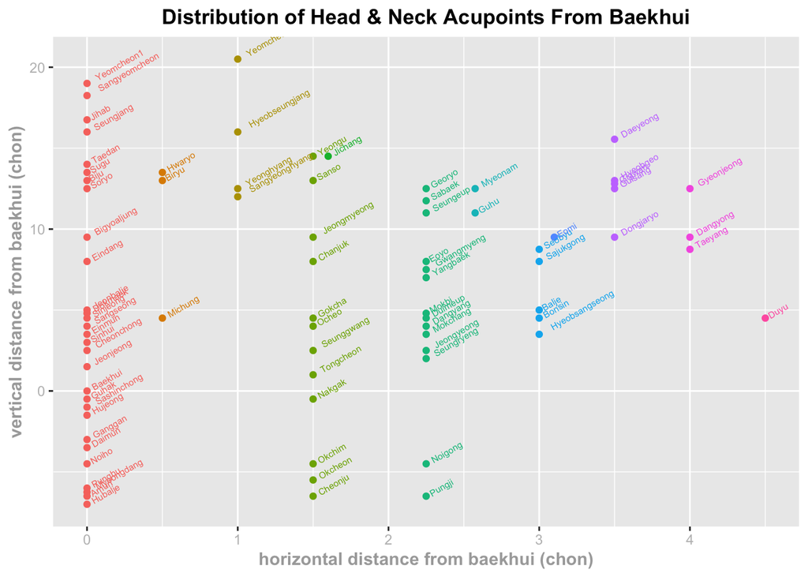

```r
ggplot(loc, aes(x, y, colour=factor(x))) + geom_point() + geom_text(aes(label=rownames(loc)), angle=30, hjust=-.2, cex=2) + labs(title='Distribution of Head & Neck Acupoints From Baekhui', x='horizontal distance from baekhui (chon)', y='vertical distance from baekhui (chon)') + theme(plot.title=element_text(size=13, face='bold', hjust=.5), axis.title=element_text(color='dark gray', face='bold'), axis.text.x=element_text(color='gray'), axis.text.y=element_text(color='gray'), legend.position='none')
```

# 2 Indications of Acupoints

All the indications of listed acupoints are aligned in an alphabetical order below using ‘Meridian and Acupoint’ lecture notes as a reference. Here the value of 1 implies the specific acupoint can have therapeutic effects on the corresponding pathological category, and 0 otherwise.

```r
colnum = dim(df)[2]
ind = df[, c(1, 4:colnum)]
rownames(ind) = ind[, 1]
ind = ind[, -1]
ind
```

|  | Arrhythmia | Bad.breath | Cholecystitis | Cold | Constipation | Dementia | Drooling | Dysphonia | Eye.diseases | Facial.boil | Facial.convulsion | Facial.edema | Facial.itch | Facial.palsy | Fever | Forgetfulness | Gastritis | Hair.loss | Headache | Hearing.loss | Hemiplegia | Hemorrhoid | Hiccup | Hypertension | Insomnia | Intermittent.fever | Jaundice | Laryngopharyngitis | Lethargy | … |
| --- | --- | --- | --- | --- | --- | --- | --- | --- | --- | --- | --- | --- | --- | --- | --- | --- | --- | --- | --- | --- | --- | --- | --- | --- | --- | --- | --- | --- | --- | --- |
| Hubalje | 0 | 0 | 0 | 0 | 0 | 0 | 0 | 0 | 0 | 0 | 0 | 0 | 0 | 0 | 0 | 0 | 0 | 0 | 0 | 0 | 0 | 0 | 0 | 0 | 0 | 0 | 0 | 0 | 0 | … |
| Amun | 0 | 0 | 0 | 0 | 0 | 0 | 0 | 1 | 0 | 0 | 0 | 0 | 0 | 0 | 0 | 0 | 0 | 0 | 1 | 0 | 0 | 0 | 0 | 0 | 0 | 0 | 0 | 0 | 0 | … |
| Cheonju | 0 | 0 | 0 | 0 | 0 | 0 | 0 | 0 | 1 | 0 | 0 | 0 | 0 | 0 | 1 | 0 | 0 | 0 | 1 | 0 | 0 | 0 | 0 | 0 | 0 | 0 | 0 | 0 | 0 | … |
| Pungji | 0 | 0 | 0 | 0 | 0 | 0 | 0 | 0 | 1 | 0 | 0 | 0 | 0 | 0 | 1 | 0 | 0 | 0 | 1 | 1 | 0 | 0 | 0 | 0 | 0 | 0 | 0 | 0 | 0 | … |
| Myeongdang | 0 | 0 | 0 | 1 | 0 | 0 | 0 | 0 | 0 | 0 | 0 | 0 | 0 | 0 | 0 | 0 | 0 | 0 | 1 | 0 | 0 | 0 | 0 | 0 | 0 | 0 | 0 | 0 | 0 | … |
| Pungbu | 0 | 0 | 0 | 0 | 0 | 0 | 0 | 1 | 1 | 0 | 0 | 0 | 0 | 0 | 0 | 0 | 0 | 0 | 1 | 0 | 0 | 0 | 0 | 0 | 0 | 0 | 0 | 1 | 0 | … |
| Okcheon | 0 | 0 | 0 | 0 | 0 | 0 | 0 | 1 | 0 | 0 | 0 | 0 | 0 | 0 | 0 | 0 | 0 | 0 | 0 | 0 | 0 | 0 | 0 | 0 | 0 | 0 | 0 | 0 | 0 | … |
| Noiho | 0 | 0 | 0 | 0 | 0 | 0 | 0 | 1 | 0 | 0 | 0 | 0 | 0 | 0 | 0 | 0 | 0 | 0 | 0 | 0 | 0 | 0 | 0 | 0 | 0 | 0 | 0 | 0 | 0 | … |
| Okchim | 0 | 0 | 0 | 0 | 0 | 0 | 0 | 0 | 1 | 0 | 0 | 0 | 0 | 0 | 0 | 0 | 0 | 0 | 1 | 0 | 0 | 0 | 0 | 0 | 0 | 0 | 0 | 0 | 0 | … |
| Noigong | 0 | 0 | 0 | 0 | 0 | 0 | 0 | 0 | 1 | 0 | 0 | 0 | 0 | 0 | 1 | 0 | 0 | 0 | 1 | 1 | 0 | 0 | 0 | 0 | 0 | 0 | 0 | 0 | 0 | … |

[output cut: 70 more lines]

# 3 Clustering Acupoints according to Coordinates

Using the hierarchical clustering algorithm, the above acupoints are grouped according to x, y coordinates. They are categorized into several subgroups.

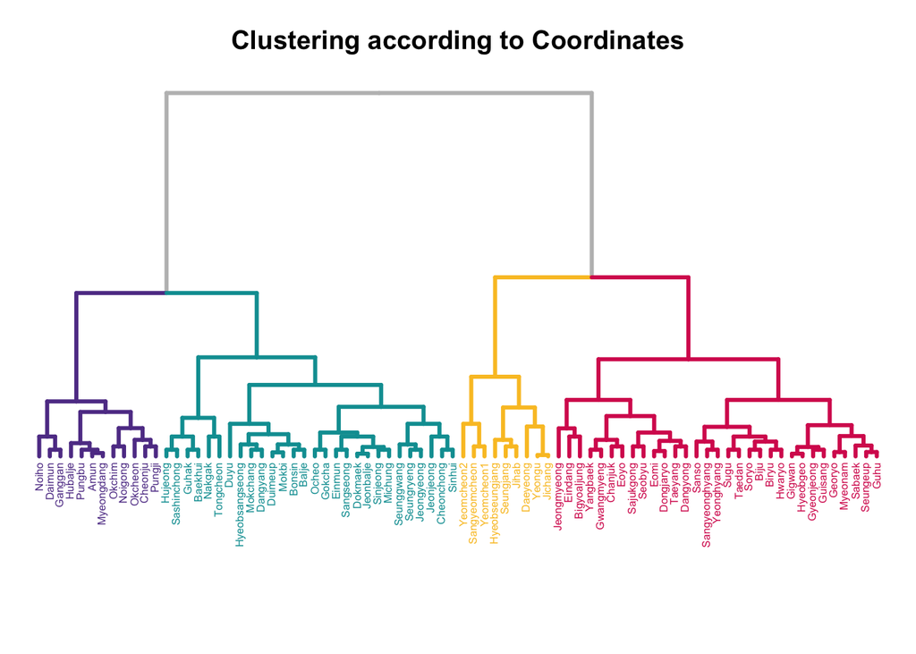

```r
loc %>% dist() %>% hclust() %>% as.dendrogram() -> locdend
par(mar=c(7, 0, 3, 0))
locdend %>% set('labels_col', value=c('#603E95',  '#009DA1', '#FAC22B', '#D7255D'), k=4) %>% set('branches_col', 'gray') %>% set('branches_lwd', 3) %>% set('branches_k_color', value=c('#603E95', '#009DA1', '#FAC22B', '#D7255D'), k=4) %>% set('labels_cex', .5) %>% plot(main='Clustering according to Coordinates', cex.main=1.2, axes=F)
```

# 4 Clustering Acupoints according to Indications

Likewise in the previous section, those acupoints were classified according to indications. Four subgroups are marked below with different colors as in the case of coordinates, but it has different depths and structures.

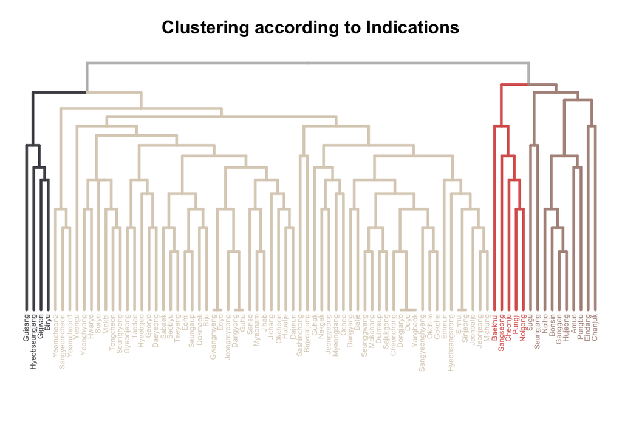

```r
ind %>% dist() %>% hclust() %>% as.dendrogram() -> inddend
par(mar=c(7, 0, 3, 0))
inddend %>% set('labels_col', value=c('#4E4E56', '#DCD0C0', '#DA635D', '#B1938B'), k=4) %>% set('branches_col', 'gray') %>% set('branches_lwd', 3) %>% set('branches_k_color', value=c('#4E4E56', '#DCD0C0', '#DA635D', '#B1938B'), k=4) %>% set('labels_cex', .5) %>% plot(main='Clustering according to Indications', cex.main=1.2, axes=F)
```

# 5 Tanglegram : Matching Two Clusterings

Whether the above two clustermaps have a good match or not can be tested by the method of tanglogram. A tanglegram gives two dendrograms facing each other connected by a line which visualizes the consistancy of groupings. If there exists major portions of parallel lines between two trees, then it can be said that locations of acupoints are correlated with those indications on basis of so-far knowledge. It can be well-quantified by a number called ‘entanglement’ which measures the normalized euclidean distance between the two tree-size dimensional vectors. As a result, a low entanglement score quantifies how unfluctuating the grouping is.

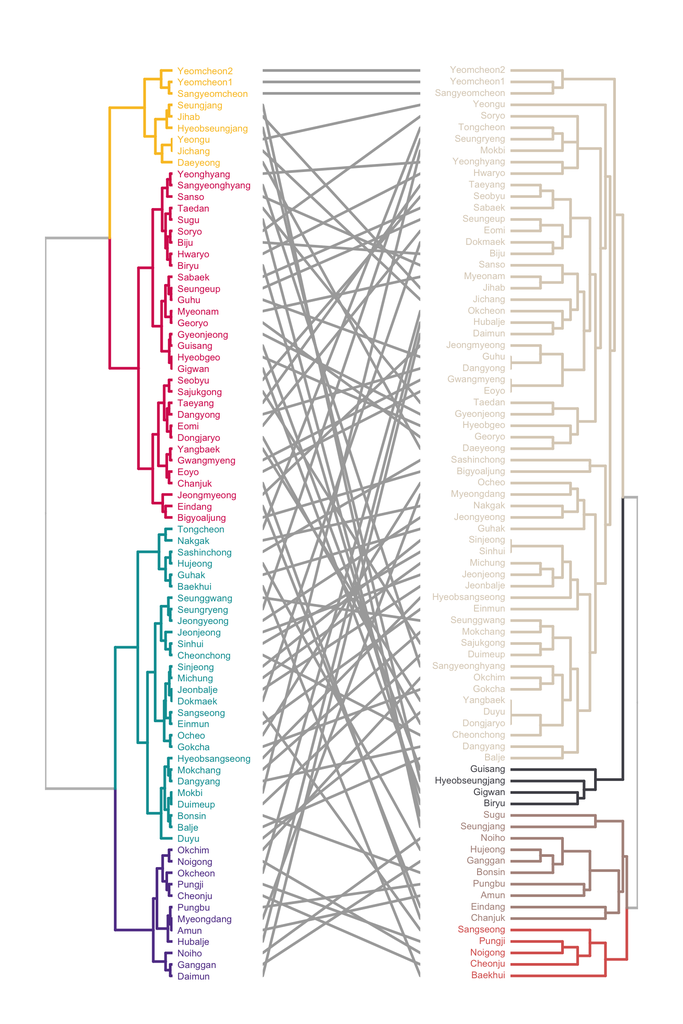

[output not shown]

```r
entanglement(dl)
```

```
## [1] 0.8275726
```

The entanglement for comparing two trees is high which shows poor matches.

# 6 Extrapolating Indications in terms of Coordinate Cluster

Although the locations and indications of acupoints are pattenless based on current knowledge, hypothetical therapeutic effects could possibly be attained as a final step. Given that our understanding of acupoint therapeutics is not enough, potential therapeutic effects of acupoints can be produced by an educated guess that indications of acupoints can be extended in line with locations. Provided data coordinates were grouped by four sub-trees as mentioned before, here however, those groups were divided again to a deeper level and boxed by dotted lines. This borderline is set with refering subject matter knowledge, but is eventually arbitrary. Therefore, the total number of subgroups is a parameter of this argument. As an example of many more cases, it is set to be twelve here and possible therapeutic effects are induced by the union of indications of those elements in respective subgroups.

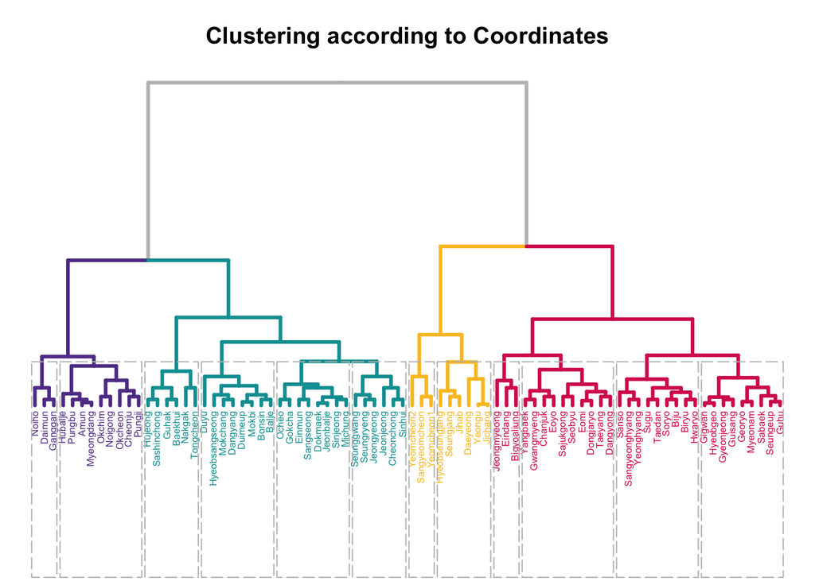

```r
par(mar=c(7, 0, 3, 0))
loc %>% dist() %>% hclust() %>% as.dendrogram() -> locdend
locdend %>% set('labels_col', value=c('#603E95',  '#009DA1', '#FAC22B', '#D7255D'), k=4) %>% set('branches_col', 'gray') %>% set('branches_lwd', 3) %>% set('branches_k_color', value=c('#603E95', '#009DA1', '#FAC22B', '#D7255D'), k=4) %>% set('labels_cex', .5) %>% plot(main='Clustering according to Coordinates', cex.main=1.2, axes=F)
locdend %>% rect.dendrogram(k=12, border=8, lty=5, lwd =1)
```

## 6.1 1st subgroup : Noiho, Daimun Ganggan

The first subgroup of which members are Noiho, Daimun, Ganggan is analyzed to have positive therapeutic effects on,

```r
grp = c('Noiho', 'Daimun', 'Ganggan')
colnms = c()
for (i in 1:length(grp)) {
  colidx = which(ind[grp[i], ] == 1)
  colnm = colnames(ind)[colidx]
  colnms = c(colnms, colnm)
}
sort(unique(colnms))
```

```
## [1] "Dysphonia"  "Headache"   "Hemiplegia" "Neck.pain"  "Psychosis"
## [6] "Seizure"    "Vertigo"
```

## 6.2 2nd subgroup : Hubalje, Pungbu, Amun, Myeongdang, Okchim, Noigong, Okcheon, Cheonju, Pungji

The second subgroup of which members are Hubalje, Pungbu, Amun, Myeongdang, Okchim, Noigong, Okcheon, Cheonju, Pungji is analyzed to have positive therapeutic effects on,

```r
grp = c('Hubalje', 'Pungbu', 'Amun', 'Myeongdang', 'Okchim', 'Noigong', 'Okcheon', 'Cheonju', 'Pungji')
colnms = c()
for (i in 1:length(grp)) {
  colidx = which(ind[grp[i], ] == 1)
  colnm = colnames(ind)[colidx]
  colnms = c(colnms, colnm)
}
sort(unique(colnms))
```

```
##  [1] "Cold"               "Dysphonia"          "Eye.diseases"
##  [4] "Fever"              "Headache"           "Hearing.loss"
##  [7] "Laryngopharyngitis" "Neck.pain"          "Nose.bleeding"
## [10] "Psychosis"          "Rhinitis"           "Seizure"
## [13] "Shoulder.pain"      "Stroke"             "Tinnitus"
## [16] "Tongue.palsy"       "Vertigo"
```

## 6.3 3rd subgroup : Hujeong, Sashinchong, Guhak, Baekhui, Nakgak, Tongcheon

The third subgroup of which members are Hujeong, Sashinchong, Guhak, Baekhui, Nakgak, Tongcheon is analyzed to have positive therapeutic effects on,

```r
grp = c('Hujeong', 'Sashinchong', 'Guhak', 'Baekhui', 'Nakgak', 'Tongcheon')
colnms = c()
for (i in 1:length(grp)) {
  colidx = which(ind[grp[i], ] == 1)
  colnm = colnames(ind)[colidx]
  colnms = c(colnms, colnm)
}
sort(unique(colnms))
```

```
##  [1] "Dementia"           "Eye.diseases"       "Forgetfulness"
##  [4] "Hair.loss"          "Headache"           "Hemiplegia"
##  [7] "Hemorrhoid"         "Insomnia"           "Intermittent.fever"
## [10] "Neck.pain"          "Nose.bleeding"      "Psychosis"
## [13] "Rhinitis"           "Seizure"            "Stroke"
## [16] "Tinnitus"           "Unconsciousness"    "Uterine.prolapse"
## [19] "Vertigo"
```

## 6.4 4th subgroup : Duyu, Hyeobsangseong, Mokchang, Dangyang, Duimeup, Mokbi, Bonsin, Balje

The fourth subgroup of which members are Duyu, Hyeobsangseong, Mokchang, Dangyang, Duimeup, Mokbi, Bonsin, Balje is analyzed to have positive therapeutic effects on,

```r
grp = c('Duyu', 'Hyeobsangseong', 'Mokchang', 'Dangyang', 'Duimeup', 'Mokbi', 'Bonsin', 'Balje')
colnms = c()
for (i in 1:length(grp)) {
  colidx = which(ind[grp[i], ] == 1)
  colnm = colnames(ind)[colidx]
  colnms = c(colnms, colnm)
}
sort(unique(colnms))
```

```
##  [1] "Arrhythmia"    "Cholecystitis" "Cold"          "Eye.diseases"
##  [5] "Facial.boil"   "Facial.palsy"  "Gastritis"     "Headache"
##  [9] "Neck.pain"     "Nose.bleeding" "Rhinitis"      "Seizure"
## [13] "Stroke"        "Vertigo"
```

## 6.5 5th subgroup : Ocheo, Gokcha, Einmun, Sangseong, Dokmaek, Jeonbalje, Sinjeong, Michung

The fifth subgroup of which members are Ocheo, Gokcha, Einmun, Sangseong, Dokmaek, Jeonbalje, Sinjeong, Michung is analyzed to have positive therapeutic effects on,

```r
grp = c('Ocheo', 'Gokcha', 'Einmun', 'Sangseong', 'Dokmaek', 'Jeonbalje', 'Sinjeong', 'Michung')
colnms = c()
for (i in 1:length(grp)) {
  colidx = which(ind[grp[i], ] == 1)
  colnm = colnames(ind)[colidx]
  colnms = c(colnms, colnm)
}
sort(unique(colnms))
```

```
##  [1] "Cold"               "Eye.diseases"       "Facial.convulsion"
##  [4] "Facial.palsy"       "Fever"              "Headache"
##  [7] "Hypertension"       "Intermittent.fever" "Jaundice"
## [10] "Nose.bleeding"      "Psychosis"          "Rhinitis"
## [13] "Seizure"            "Vertigo"
```

## 6.6 6th subgroup : Seunggwang, Seungryeong, Jeongyeong, Jeonjeong, Cheonchong, Sinhui

The sixth subgroup of which members are Seunggwang, Seungryeong, Jeongyeong, Jeonjeong, Cheonchong, Sinhui is analyzed to have positive therapeutic effects on,

```r
grp = c('Seunggwang','Seungryeong', 'Jeongyeong', 'Jeonjeong', 'Cheonchong', 'Sinhui')
colnms = c()
for (i in 1:length(grp)) {
  colidx = which(ind[grp[i], ] == 1)
  colnm = colnames(ind)[colidx]
  colnms = c(colnms, colnm)
}
sort(unique(colnms))
```

```
##  [1] "Cold"          "Eye.diseases"  "Facial.edema"  "Headache"
##  [5] "Nose.bleeding" "Psychosis"     "Rhinitis"      "Seizure"
##  [9] "Toothache"     "Vertigo"
```

## 6.7 7th subgroup : Yeomcheon1, Yeomcheon2, Sangyeomcheon

The seventh subgroup of which members are Sangyeomcheon and both Yeomcheons which are written in code as Yeomcheon1, Yeomcheon2 is analyzed to have positive therapeutic effects on,

```r
grp = c('Yeomcheon1', 'Yeomcheon2', 'Sangyeomcheon')
colnms = c()
for (i in 1:length(grp)) {
  colidx = which(ind[grp[i], ] == 1)
  colnm = colnames(ind)[colidx]
  colnms = c(colnms, colnm)
}
sort(unique(colnms))
```

```
## [1] "Drooling"            "Dysphonia"           "Intermittent.fever"
## [4] "Laryngopharyngitis"  "Swallowing.disorder" "Tongue.palsy"
## [7] "Tongue.ulcer"
```

## 6.8 8th subgroup : Hyeobseungjang, Seungjang, Jihab, Daeyeong, Yeongu, Jichang

The eighth subgroup of which members are Hyeobseungjang, Seungjang, Jihab, Daeyeong, Yeongu, Jichang is analyzed to have positive therapeutic effects on,

```r
grp = c('Hyeobseungjang', 'Seungjang', 'Jihab', 'Daeyeong', 'Yeongu', 'Jichang')
colnms = c()
for (i in 1:length(grp)) {
  colidx = which(ind[grp[i], ] == 1)
  colnm = colnames(ind)[colidx]
  colnms = c(colnms, colnm)
}
sort(unique(colnms))
```

```
##  [1] "Constipation"         "Drooling"             "Dysphonia"
##  [4] "Facial.boil"          "Facial.convulsion"    "Facial.edema"
##  [7] "Facial.palsy"         "Headache"             "Jaundice"
## [10] "Neck.pain"            "Periodontitis"        "Polydipsia"
## [13] "Psychosis"            "Seizure"              "Stroke"
## [16] "Toothache"            "Trigeminal.neuralgia" "Urinary.retention"
```

## 6.9 9th subgroup : Jeongmyeong, Eindang, Bigyoaljung

The ninth subgroup of which members are Jeongmyeong, Eindang, Bigyoaljung is analyzed to have positive therapeutic effects on,

```r
grp = c('Jeongmyeong', 'Eindang', 'Bigyoaljung')
colnms = c()
for (i in 1:length(grp)) {
  colidx = which(ind[grp[i], ] == 1)
  colnm = colnames(ind)[colidx]
  colnms = c(colnms, colnm)
}
sort(unique(colnms))
```

```
##  [1] "Eye.diseases"         "Facial.palsy"         "Forgetfulness"
##  [4] "Headache"             "Hypertension"         "Insomnia"
##  [7] "Jaundice"             "Lethargy"             "Nervous.breakdown"
## [10] "Rhinitis"             "Seizure"              "Trigeminal.neuralgia"
## [13] "Unconsciousness"      "Vertigo"
```

## 6.10 10th subgroup : Yangbaek, Gwangmyeng, Chanjuk, Eoyo, Sajukgong, Seobyu, Eomi, Dongjaryo, Taeyang, Dangyong

The tenth subgroup of which members are Yangbaek, Gwangmyeng, Chanjuk, Eoyo, Sajukgong, Seobyu, Eomi, Dongjaryo, Taeyang, Dangyong is analyzed to have positive therapeutic effects on,

```r
grp = c('Yangbaek', 'Gwangmyeng', 'Chanjuk', 'Eoyo', 'Sajukgong', 'Seobyu', 'Eomi', 'Dongjaryo', 'Taeyang', 'Dangyong')
colnms = c()
for (i in 1:length(grp)) {
  colidx = which(ind[grp[i], ] == 1)
  colnm = colnames(ind)[colidx]
  colnms = c(colnms, colnm)
}
sort(unique(colnms))
```

```
##  [1] "Cold"                     "Eye.diseases"
##  [3] "Facial.convulsion"        "Facial.palsy"
##  [5] "Headache"                 "Hemorrhoid"
##  [7] "Hiccup"                   "Pain.in.the.eyebrow.area"
##  [9] "Ptosis"                   "Seizure"
## [11] "Vertigo"
```

## 6.11 11th subgroup : Sanso, Sangyeonghyang, Yeonghyang, Sugu, Taedan, Soryo, Biju, Biryu, Hwaryo

The eleventh subgroup of which members are Sanso, Sangyeonghyang, Yeonghyang, Sugu, Taedan, Soryo, Biju, Biryu, Hwaryo is analyzed to have positive therapeutic effects on,

```r
grp = c('Sanso', 'Sangyeonghyang', 'Yeonghyang', 'Sugu', 'Taedan', 'Soryo', 'Biju', 'Biryu', 'Hwaryo')
colnms = c()
for (i in 1:length(grp)) {
  colidx = which(ind[grp[i], ] == 1)
  colnm = colnames(ind)[colidx]
  colnms = c(colnms, colnm)
}
sort(unique(colnms))
```

```
##  [1] "Bad.breath"           "Eye.diseases"         "Facial.boil"
##  [4] "Facial.convulsion"    "Facial.edema"         "Facial.itch"
##  [7] "Facial.palsy"         "Headache"             "Nose.bleeding"
## [10] "Polydipsia"           "Psychosis"            "Rhinitis"
## [13] "Rosaceae"             "Sacral.pain"          "Seizure"
## [16] "Stroke"               "Toothache"            "Trigeminal.neuralgia"
## [19] "Unconsciousness"
```

## 6.12 12th subgroup : Gigwan, Hyeobgeo, Gyeonjeong, Guisang, Georyo, Myeonam, Sabaek, Seungeup, Guhu

The twelfth subgroup of which members are Gigwan, Hyeobgeo, Gyeonjeong, Guisang, Georyo, Myeonam, Sabaek, Seungeup, Guhu is analyzed to have positive therapeutic effects on,

```r
grp = c('Gigwan', 'Hyeobgeo', 'Gyeonjeong', 'Guisang', 'Georyo', 'Myeonam', 'Sabaek', 'Seungeup', 'Guhu')
colnms = c()
for (i in 1:length(grp)) {
  colidx = which(ind[grp[i], ] == 1)
  colnm = colnames(ind)[colidx]
  colnms = c(colnms, colnm)
}
sort(unique(colnms))
```

```
##  [1] "Bad.breath"                 "Eye.diseases"
##  [3] "Facial.boil"                "Facial.convulsion"
##  [5] "Facial.edema"               "Facial.palsy"
##  [7] "Headache"                   "Hearing.loss"
##  [9] "Neck.pain"                  "Parotitis"
## [11] "Periodontitis"              "Stroke"
## [13] "Temporomandibular.disorder" "Tinnitus"
## [15] "Toothache"                  "Trigeminal.neuralgia"
## [17] "Vertigo"
```